# Data analysis project Titanic dataset

Data analysis: Project Titanic dataset

Dataset

In 1912, the ship RMS Titanic struck an iceberg on its maiden voyage and sank, resulting in the deaths of most of its passengers and crew. The data contains demographics and voyage information from 891 of the 2224 passengers and crew on board the ship. This link allows reading the description of this dataset on the Kaggle website, where the data was obtained. https://www.kaggle.com.

In this project, the most interesting variable I could observe here is "Survived". The main question is: What factors made people more likely to survive?

We are going to review the factors whether the number of survivors was dependent on their age, sex, social status (class and fare).

In this purpose first we can analysis material status of passengers, having considered fares by classes.

Then we can analysis how many people survived having considered them by class and by sex.

Also we can analysis Age of survived passengers, having considered minimum and maximum age of survived passengers, how many children survived and so on.

First of all, we have to exract data from the file (titanic-data) and look at the available indicators.

```python
import pandas as pd
import numpy as np
import matplotlib.pyplot as plt
import seaborn as sns

def percentages_xy(x,y):
    return 100.0*x/y

titanic = pd.read_csv('titanic-data.csv')
```

```python
titanic[1:8]
```

|  | PassengerId | Survived | Pclass | Name | Sex | Age | SibSp | Parch | Ticket | Fare | Cabin | Embarked |
| --- | --- | --- | --- | --- | --- | --- | --- | --- | --- | --- | --- | --- |
| 1 | 2 | 1 | 1 | Cumings, Mrs. John Bradley (Florence Briggs Th... | female | 38.0 | 1 | 0 | PC 17599 | 71.2833 | C85 | C |
| 2 | 3 | 1 | 3 | Heikkinen, Miss. Laina | female | 26.0 | 0 | 0 | STON/O2. 3101282 | 7.9250 | NaN | S |
| 3 | 4 | 1 | 1 | Futrelle, Mrs. Jacques Heath (Lily May Peel) | female | 35.0 | 1 | 0 | 113803 | 53.1000 | C123 | S |
| 4 | 5 | 0 | 3 | Allen, Mr. William Henry | male | 35.0 | 0 | 0 | 373450 | 8.0500 | NaN | S |
| 5 | 6 | 0 | 3 | Moran, Mr. James | male | NaN | 0 | 0 | 330877 | 8.4583 | NaN | Q |
| 6 | 7 | 0 | 1 | McCarthy, Mr. Timothy J | male | 54.0 | 0 | 0 | 17463 | 51.8625 | E46 | S |
| 7 | 8 | 0 | 3 | Palsson, Master. Gosta Leonard | male | 2.0 | 3 | 1 | 349909 | 21.0750 | NaN | S |

The number of passengers in the data sample

```python
len(titanic)
```

```
891
```

```python
titanic.tail()
```

|  | PassengerId | Survived | Pclass | Name | Sex | Age | SibSp | Parch | Ticket | Fare | Cabin | Embarked |
| --- | --- | --- | --- | --- | --- | --- | --- | --- | --- | --- | --- | --- |
| 886 | 887 | 0 | 2 | Montvila, Rev. Juozas | male | 27.0 | 0 | 0 | 211536 | 13.00 | NaN | S |
| 887 | 888 | 1 | 1 | Graham, Miss. Margaret Edith | female | 19.0 | 0 | 0 | 112053 | 30.00 | B42 | S |
| 888 | 889 | 0 | 3 | Johnston, Miss. Catherine Helen "Carrie" | female | NaN | 1 | 2 | W./C. 6607 | 23.45 | NaN | S |
| 889 | 890 | 1 | 1 | Behr, Mr. Karl Howell | male | 26.0 | 0 | 0 | 111369 | 30.00 | C148 | C |
| 890 | 891 | 0 | 3 | Dooley, Mr. Patrick | male | 32.0 | 0 | 0 | 370376 | 7.75 | NaN | Q |

Data Wragling and Cleaning Phase.

Descriptions. survival: Survival (0 = No; 1 = Yes) pclass: Passenger Class (1 = 1st; 2 = 2nd; 3 = 3rd) name: Name sex: Sex age: Age sibsp: Number of Siblings/Spouses Aboard parch: Number of Parents/Children Aboard ticket: Ticket Number fare: Passenger Fare cabin: Cabin embarked: Port of Embarkation (C = Cherbourg; Q = Queenstown; S = Southampton)

After investigating the data descriptions, we need clean them up from inconsistencies or problems in the data to create our model for further to explore it. It is important determine what elements or values need to answer our questions. For example in dataset some columns will not play a part in our analysis and these columns can be removed. It could help with processing performance of the dataset. Then some values for Age column are missing values with NAN.

Removing unnecessary column (Name, Ticket, Cabin, Embarked)

```python
titanic_cleaned = titanic.drop(['SibSp','Parch','Name',
                                          'Ticket','Cabin',
                                'Embarked'], axis=1)
titanic_cleaned[1:8]
```

|  | PassengerId | Survived | Pclass | Sex | Age | Fare |
| --- | --- | --- | --- | --- | --- | --- |
| 1 | 2 | 1 | 1 | female | 38.0 | 71.2833 |
| 2 | 3 | 1 | 3 | female | 26.0 | 7.9250 |
| 3 | 4 | 1 | 1 | female | 35.0 | 53.1000 |
| 4 | 5 | 0 | 3 | male | 35.0 | 8.0500 |
| 5 | 6 | 0 | 3 | male | NaN | 8.4583 |
| 6 | 7 | 0 | 1 | male | 54.0 | 51.8625 |
| 7 | 8 | 0 | 3 | male | 2.0 | 21.0750 |

Number of missing values

```python
titanic_cleaned.isnull().sum()
```

```
PassengerId      0
Survived         0
Pclass           0
Sex              0
Age            177
Fare             0
dtype: int64
```

Review some of the missing Age data

```python
missing_age = pd.isnull(titanic_cleaned['Age'])
titanic_cleaned[missing_age].head()
```

|  | PassengerId | Survived | Pclass | Sex | Age | Fare |
| --- | --- | --- | --- | --- | --- | --- |
| 5 | 6 | 0 | 3 | male | NaN | 8.4583 |
| 17 | 18 | 1 | 2 | male | NaN | 13.0000 |
| 19 | 20 | 1 | 3 | female | NaN | 7.2250 |
| 26 | 27 | 0 | 3 | male | NaN | 7.2250 |
| 28 | 29 | 1 | 3 | female | NaN | 7.8792 |

```python
titanic_cleaned.info()
```

```
<class 'pandas.core.frame.DataFrame'>
RangeIndex: 891 entries, 0 to 890
Data columns (total 6 columns):
PassengerId    891 non-null int64
Survived       891 non-null int64
Pclass         891 non-null int64
Sex            891 non-null object
Age            714 non-null float64
Fare           891 non-null float64
dtypes: float64(2), int64(3), object(1)
memory usage: 41.8+ KB
```

Determine number of males and females with missing age values

```python
missing_age_female = titanic_cleaned[missing_age]['Sex'] == 'female'
missing_age_male = titanic_cleaned[missing_age]['Sex'] == 'male'

print "Number of age missing for female {}".format(missing_age_female.sum())
print "Number of age missing for male {}".format(missing_age_male.sum())
```

```
Number of age missing for female 53
Number of age missing for male 124
```

These are missing data could affect to our analysis since there is a large gap in total between survived and age columns. For example, it could affect to determine the exact average age and the trends in age categories. Then accordingly the distribution of them may be changed significantly. Also it could affect to answer our question as the factor ages influenced on the number of survivors.

Data Exploration and Visualization Phase.

In order to summarize and describe exploring data, we need to perform descriptive statistics.

Descriptive statistics

```python
titanic_cleaned.describe()
```

|  | PassengerId | Survived | Pclass | Age | Fare |
| --- | --- | --- | --- | --- | --- |
| count | 891.000000 | 891.000000 | 891.000000 | 714.000000 | 891.000000 |
| mean | 446.000000 | 0.383838 | 2.308642 | 29.699118 | 32.204208 |
| std | 257.353842 | 0.486592 | 0.836071 | 14.526497 | 49.693429 |
| min | 1.000000 | 0.000000 | 1.000000 | 0.420000 | 0.000000 |
| 25% | 223.500000 | 0.000000 | 2.000000 | 20.125000 | 7.910400 |
| 50% | 446.000000 | 0.000000 | 3.000000 | 28.000000 | 14.454200 |
| 75% | 668.500000 | 1.000000 | 3.000000 | 38.000000 | 31.000000 |
| max | 891.000000 | 1.000000 | 3.000000 | 80.000000 | 512.329200 |

```
array([[<matplotlib.axes._subplots.AxesSubplot object at 0x0000000014F8A7F0>,
        <matplotlib.axes._subplots.AxesSubplot object at 0x0000000015418A20>]], dtype=object)
```

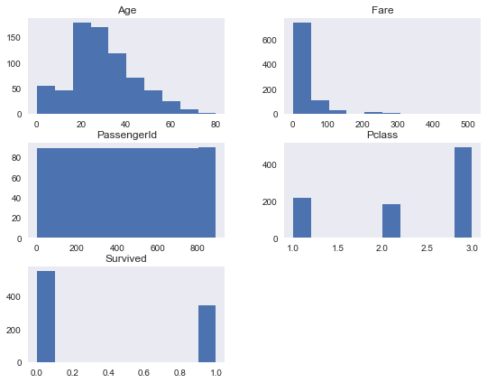

```python
titanic_cleaned.hist(bins=10,figsize=(9,7),grid=False)
```

From above descriptive statistics we can consider how much did fare cost by Pclass.

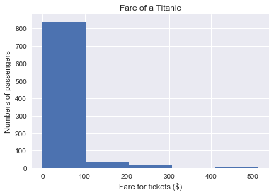

```python
titanic_cleaned.hist('Fare', bins = 5)
plt.xlabel("Fare for tickets ($)")
plt.ylabel("Numbers of passengers")
plt.title("Fare of a Titanic")
```

On this distribution histogram we can find out that minimum fare was 0$. It could be for crew team on the board or probably people who won prise of free trip.

And maximum fare about 513$. I guess this price was only for couple of VIP people.

Futher on this boxplot we can see average fare by Pclass of passengers. It looks like difference of average fare between second and third class wasn't so big.

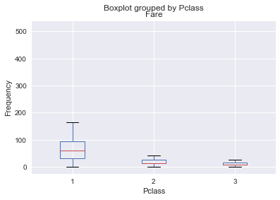

```python
titanic.boxplot(column = ['Fare'],by = ['Pclass'])
pd.DataFrame(titanic.groupby(['Pclass'])['Fare'].describe().loc[:,['mean', 'std']])
plt.xlabel('Pclass')
plt.ylabel('Frequency')
```

Now lets get started in the analysis by looking at sum of surviving passengers. It is 342 out of the 891 people in our dataset survived, which consist about 38% .

Number of survivors in the data sample

```python
titanic['Survived'].sum()
```

```
342
```

Determine what kind of Pclasses were on the ship

```python
pclass = pd.Series(titanic['Pclass'])
pclass_list = list(set(pclass.values))
pclass_list
```

```
[1, 2, 3]
```

After we can determine number of passengers and survived for each Pclass

```python
number_by_pclass = titanic.groupby('Pclass').count()['PassengerId']
survived_by_pclass = titanic.groupby('Pclass').sum()['Survived']

number_by_pclass_df = pd.DataFrame(data={'Number by Pclass': number_by_pclass,
                                         'Survived by Pclass':survived_by_pclass})
number_by_pclass_df
```

| Pclass | Number by Pclass | Survived by Pclass |
| --- | --- | --- |
| 1 | 216 | 136 |
| 2 | 184 | 87 |
| 3 | 491 | 119 |

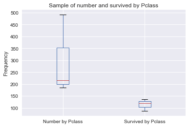

```python
% pylab inline
number_by_pclass_df.boxplot()
plt.title('Sample of number and survived by Pclass')
plt.ylabel('Frequency')
```

Now we need to consider number of passengers and survived by sex

```python
number_by_sex = titanic.groupby('Sex').count()['PassengerId']
survived_by_sex = titanic.groupby('Sex').sum()['Survived']
survived_by_sex_df = pd.DataFrame(data={'Number by sex': number_by_sex,
                                        'Survived by sex': survived_by_sex})
survived_by_sex_df
```

| Sex | Number by sex | Survived by sex |
| --- | --- | --- |
| female | 314 | 233 |
| male | 577 | 109 |

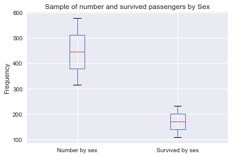

```python
% pylab inline
survived_by_sex_df.boxplot()
plt.title('Sample of number and survived passengers by Sex')
plt.ylabel('Frequency')
```

```python
titanic.groupby(['Pclass','Sex'])[['Survived']].mean()
```

| Pclass | Sex | Survived |
| --- | --- | --- |
| 1 | female | 0.968085 |
|  | male | 0.368852 |
| 2 | female | 0.921053 |
|  | male | 0.157407 |
| 3 | female | 0.500000 |
|  | male | 0.135447 |

| Sex | Pclass | Survived |
| --- | --- | --- |
| female | 1 | 0.968085 |
|  | 2 | 0.921053 |
|  | 3 | 0.500000 |
| male | 1 | 0.368852 |
|  | 2 | 0.157407 |
|  | 3 | 0.135447 |

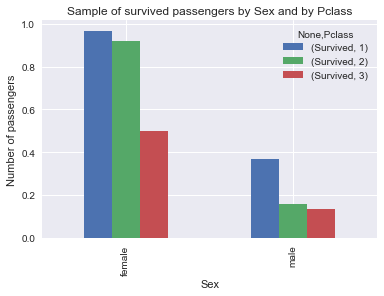

```python
titanic.groupby(['Sex','Pclass'])[['Survived']].mean().unstack().plot(kind = 'bar')
plt.ylabel('Number of passengers')
plt.xlabel('Sex')
plt.title('Sample of survived passengers by Sex and by Pclass')
titanic.groupby(['Sex','Pclass'])[['Survived']].mean()
```

Here We are going to group the passengers on the basis of age and consider their distribution

|  | Age |
| --- | --- |
| count | 714.000000 |
| mean | 29.699118 |
| std | 14.526497 |
| min | 0.420000 |
| 25% | 20.125000 |
| 50% | 28.000000 |
| 75% | 38.000000 |
| max | 80.000000 |

[figure not shown]

```python
number_age = titanic.groupby('Age').count()['PassengerId']
ax = titanic['Age'].hist(bins = 5)
ax.set_ylabel("Number of survived passengers")
ax.set_xlabel("Age")
ax.set_title('Sample of survived passengers by age')
pd.DataFrame(titanic['Age'].describe())
```

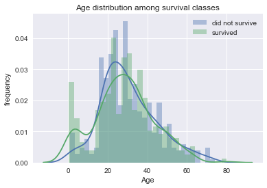

```python
sns.distplot(titanic.loc[(titanic['Survived']==0) & (~titanic['Age'].isnull()),'Age'], bins=30)
sns.distplot(titanic.loc[(titanic['Survived']==1) & (~titanic['Age'].isnull()),'Age'], bins=30)
plt.title('Age distribution among survival classes')
plt.ylabel('frequency')
plt.legend(['did not survive', 'survived']);
```

Conclusions Phase.

Looking at the above plots, it seems to me that females had more chances to survive than males, as well as the passengers of the first class had more chances than the passengers of the second class, and they had more chances than passengers of third class.

There are a lot of limitations in this analysis.

We have the data for only 891 passengers, but in this incident there were still the rest 1333 passengers in total and the crew members. If the rest of the part of survived passengers will be more in 2nd or 3rd class, the result of all the analysis should be completely different.

Some columns have missing data and it also could affect the analysis. For example, the trends in age categories and in the distribution of them of rescued passengers may be changed significantly.

```python
number_by_pclass = titanic.groupby('Pclass').count()['PassengerId']
number_by_pclass_percent = percentages_xy(number_by_pclass,len(titanic))
survived_by_pclass = titanic.groupby('Pclass').sum()['Survived']
survived_by_pclass_percent = percentages_xy(titanic.groupby('Pclass').sum()['Survived'],
                                           titanic['Survived'].sum())
number_by_pclass_df = pd.DataFrame(data={'Number by Pclass': number_by_pclass,
                                         'Survived by Pclass':survived_by_pclass,
                                        'Number by Pclass percentage':number_by_pclass_percent,
                                        'Survived by Pclass persentage':survived_by_pclass_percent})
number_by_pclass_df
```

| Pclass | Number by Pclass | Number by Pclass percentage | Survived by Pclass | Survived by Pclass persentage |
| --- | --- | --- | --- | --- |
| 1 | 216 | 24.242424 | 136 | 39.766082 |
| 2 | 184 | 20.650954 | 87 | 25.438596 |
| 3 | 491 | 55.106622 | 119 | 34.795322 |

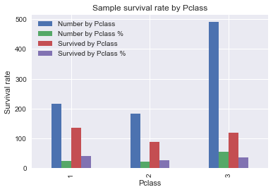

```python
number_by_pclass_df.plot(kind = 'bar')
plt.xlabel("Pclass")
plt.ylabel("Survival rate")
plt.title("Sample survival rate by Pclass")
plt.legend(["Number by Pclass", "Number by Pclass %", "Survived by Pclass", "Survived by Pclass %"])
```